# Estimation of the Bulk Rock Density using Gravity Measurements

Underground Practical Course at TUBAF *Himmelfahrt Fundgrube*

Author

Dr. Ralph-Uwe Börner  
TU Bergakademie Freiberg  
Institute of Geophysics and Geoinformatics

Published

February 16, 2026

# 1 Task

Using a *Scintrex CG-5* quartz gravity meter, the density of the Freiberg grey gneiss is to be determined by vertical difference measurements in the *Himmelfahrt Fundgrube* shaft. The results of the investigations are to be interpreted.

[figure not shown]

Gravity meter CG-5 Autograv (Scintrex Ltd.)

# 2 Theoretical background

We consider the model of an infinite horizontal plate bounded by $z=0$ and $z=h$. The gravitational effect of this plate adds to the normal attraction $\gamma_{0}$ of the ellipsoidal Earth. These two effects contribute to the gravity measured at the vertical levels $z_{1}$ and $z_{2}$:

$$\begin{align}
g(z_{1}) & = 2 \pi f \rho (h - 2 z_{1}) + \gamma_{0}(z_{1}) \\
g(z_{2}) & = 2 \pi f \rho (h - 2 z_{2}) + \gamma_{0}(z_{2})
\end{align}$$
Subtracting the second equation from the first, we obtain the block density $\rho$ with
$$\begin{align}
\rho & = \frac{1}{4 \pi f} \left(
\frac{\gamma_{0}(z_{2})-\gamma_{0}(z_{1})}{z_{2}-z_{1}}-\frac{g(z_{2}) - g(z_{1})}{z_{2}-z_{1}}
\right) \\
& = \frac{1}{4 \pi f} \left(
g_{z}-\frac{g(z_{2}) - g(z_{1})}{z_{2}-z_{1}}
\right)
\end{align}$$

with the free-air gravity gradient $g_{z} = 0.3086\ \text{mGal/m}$.

In practice, the effect of cavities, shafts, tunnels, and terrain have to be considered. Their influence is not covered by this simplified model and has thus to be accounted for by *gravity reductions*.

# 3 Experimental setup

## 3.1 Gravity measurements

For reference, a vertical cross section of the shaft is shown below. The sketch illustrates the geometric configuration of the *Himmelfahrt Fundgrube* and the surrounding rock mass and indicates the position of the gravity meter during the experiment.

[figure not shown]

Figure 1: Location of the measurement points

The gravity measurements are carried out using the **double-loop method** to ensure a reliable estimate of the instrument drift. The elevations of all measurement points are listed in Table 1.

[figure not shown]

The measurements begin at point **P0**, which serves as the **base station**. All gravity and height measurements are referenced to this point.

The drift-corrected relative gravitational acceleration is obtained from

$$\Delta g(z) = g(z,t) - g_G(z_{0}, t),$$

where $g_G(z_{0}, t)$ represents a linear interpolation through the base-point readings at fixed level $z_{0}$, from which the instrument drift correction for the corresponding measurement times is derived.

For this experiment, no connection to national gravity networks is required. Therefore, $\Delta g$ at point **P0** is arbitrarily set to zero.

## 3.2 Location of the measurement points

Table 1: Depths and elevtions of measurement points

| Point | Description | Elevation [m] | Depth $z$ [m] |
| --- | --- | --- | --- |
| P3 | Hanging bank | 428.75 | 0 |
| P2 | *Rösche* (water leat) | 362.23 | 66.52 |
| P1 | *Umbruch* (branch tunnel) | 327.82 | 100.93 |
| P0 | *1. Sohle* (base level) | 281.24 | 147.51 |
| - | *Rothschönberger Stolln* (inaccessible gallery) | 199.75 | 229.0 |

## 3.3 Reduction of the measurements

In shaft gravimetry, **free-air, Bouguer, and normal gravity reductions are omitted**.

Only the following corrections are applied:

- Gallery reduction $\delta g_{\text{G}}$
- Shaft reduction $\delta g_{\text{S}}$
- Cavity reduction $\delta g_{\text{C}}$
- Terrain reduction $\delta g_{\text{T}}$

These reductions compensate for mining-related voids by computationally refilling them with mass.

For all reductions, a uniform density of

$$\rho = 2.70 \times 10^3 \, \text{kg/m}^3$$

is assumed, corresponding approximately to the density of the Freiberg ortho-gneiss.

### 3.3.1 Gallery reduction $\delta g_{G}$

The influence of the tunnels, adits, or galleries is approximated by a **horizontal two-dimensional rectangular prism**. Required parameters are the tunnel height $H$, width $B$, and the position $(x, h)$ of the measurement point with respect to the tunnel walls.

[figure not shown]

**TipPython**

We use the *Python* function `gz_prism.py` (see Section 6).

While a right-handed coordinate system with downward-pointing $z$ is used in general, the gravity reduction is formulated here in a coordinate frame defined by the width and height of the tunnel cross section.

Consequently, the third argument in the call to gz_prism.py is `H-h`, where `H` denotes the tunnel height and `h` the elevation of the gravimeter above ground.

Note further that the infinite prism is approximated by placing the bounding planes $y=\pm\mathrm{const}$ at sufficiently large distances from the plane $y=0$.

```python
g = gz_prism(obs=(x, 0.0, H-h), prism=(0, B, -1000.0, 1000.0, 0.0, H), rho=2700)
```

### 3.3.2 Shaft reduction $\delta g_{S}$

The shaft effect is approximated by a **vertical rectangular prism**. Required parameters are the shaft dimensions defined by the diagonal between the points $(x_{1}, y_{1}, z_{1})$ and $(x_{2}, y_{2}, z_{2})$, the coordinates of the gravity meter position $(x, y, z)$, and the reduction density.

A rectangular horizontal cross section is uniquely defined by the diagonally opposite corner points $(x_1, y_1)$ and $(x_2, y_2)$, while the vertical extent ranges from $z_1$ to $z_2$. Numerical values are summarized in Table 1.

[figure not shown]

**TipPython**

We use the *Python* function `gz_prism.py`.

Here, `x`, `y`, `z` denote the coordinates of the gravity meter position. The vertical coordinate must be taken as *depth*, according to the values listed in Table 1.

```python
g = gz_prism(obs=(x, y, z), prism=(x1, x2, y1, y2, 0.0, 229.0), rho=2700)
```

### 3.3.3 Terrain reduction $\delta g_{T}$

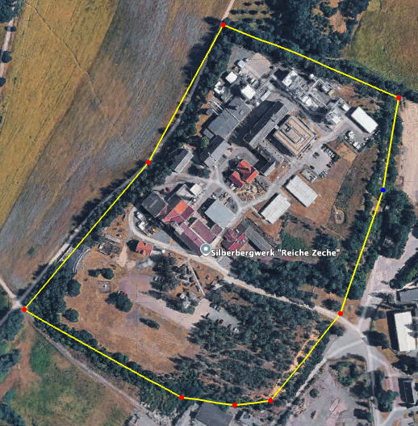

Cross-section of the stock piling area. The yellow polygon covers an area of approx. 75000 m$^2$. (Image: Google Earth)

Only the gravity effect of the stock piling is considered. The reduction is applied with respect to the stock base, located 10 m below the hanging bank. The terrain is approximated by a **three-dimensional rectangular prism**.

For measurements at **P3**, $\delta g_T > 0$.  
For all **underground** measurement points, $\delta g_T < 0$.

[figure not shown]

**TipPython**

We use the *Python* function `gz_prism.py`.

An area-equivalent rectangle is used to approximate the polygonal cross section of the pile.

[figure not shown]

### 3.3.4 Cavity Reduction $\delta g_{C}$

Right below the measurement point **P2**, a cavity (*Radstube*) is present. As a consequence, at this point a cavity reduction is required, using a **three-dimensional rectangular prism** formulation.

[figure not shown]

**TipPython**

We use the *Python* function `gz_prism.py`.

The coordinates can be taken from Figure 2.

A coordinate system with downward-pointing $z$ is adopted. The elevation of the instrument above the gallery floor must be considered. The cavity extends from $y_1 = -1.3,\mathrm{m}$ to $y_2 = +1.3,\mathrm{m}$, and the gravity meter is positioned at $y=0$.

[figure not shown]

Figure 2: Dimensions of the *Radstube* cavity.

## 3.4 Measurements

A standard form is provided for the gravity measurements.

The instrument drift correction is performed by linear interpolation.

The reduced relative gravitational acceleration is computed as

$$\Delta g_{\text{red}}
=
\Delta g
+ \delta g_{\text{G}}
+ \delta g_{\text{S}}
+ \delta g_{\text{C}}
+ \delta g_{\text{T}}.$$

If repeated measurements are available, the mean drift-corrected value $\Delta g$ must be determined first, and all reductions are applied afterwards.

### 3.4.1 Measurements and reductions

| Point | $\Delta g$ [mGal] | $\delta g_{\text{G}}$ [mGal] | $\delta g_{\text{S}}$ [mGal] | $\delta g_R$ [mGal] | $\delta g_H$ [mGal] | $\Delta g_{\text{red}}$ [mGal] |
| --- | --- | --- | --- | --- | --- | --- |
| P0 |  |  |  |  |  |  |
| P1 |  |  |  |  |  |  |
| P2 |  |  |  |  |  |  |
| P3 |  |  |  |  |  |  |

# 4 Estimation of the block density

The **block density** $\rho_B$ represents the mean density of the rock layer between two or more gravimetric measurements obtained at different depth levels.

Let $\Delta g_1(z_1)$ and $\Delta g_2(z_2)$ be the **reduced** relative gravitational accelerations at the upper and lower measurement points. Then

$$\rho_B
=
\frac{1}{4\pi f}
\left(
g_z - \frac{\Delta g_2 - \Delta g_1}{z_2 - z_1}
\right)
=
\frac{1}{4\pi f}(g_z - g_h),$$

where the free-air gravity gradient is

$$g_z = 0.3086 \ \text{mGal/m}.$$

## 4.1 Vertical gradients and block density

| Interval | $\Delta g_{2}$ [mGal] | $\Delta g_{1}$ [mGal] | $z_2 - z_1$ [m] | $g_h$ [mGal/m] | $\rho_B$ [kg/m³] |
| --- | --- | --- | --- | --- | --- |
| P0–P1 |  |  |  |  |  |
| P1–P2 |  |  |  |  |  |
| P2–P3 |  |  |  |  |  |
| P0–P3 |  |  |  |  |  |

## 4.2 Plots

The following quantities should be plotted:

- $\Delta g$, $\Delta g_{\text{red}}$, and $\Delta g_{\text{theo}}$ as functions of depth
- $\rho_B$ as a density–depth function

Here, $\Delta g_{\text{theo}}$ denotes the theoretical vertical gradient of the relative gravitational acceleration for an assumed block density of

$$\rho = 2.70 \times 10^3 \, \text{kg/m}^3.$$

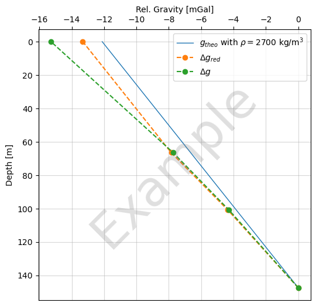

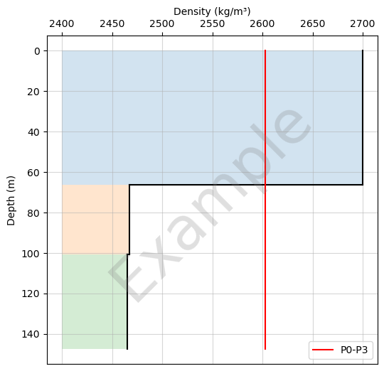

# 5 Interpretation and discussion of limitations and uncertainties

The following aspects must be discussed and their influence on the derived block density evaluated:

- Accuracy of shaft and tunnel surveying
- Instrument drift
- Terrain reduction

**TipProblem set**

- Which reduction exerts the strongest influence on the final result?
- How would you modify the reductions to obtain a more realistic estimate of the block density?
- Which implicit assumptions underlie the adopted density of the gneiss block?

# 6 Appendix

```python
import numpy as np

def gz_prism(obs=(0.0, 0.0, 0.0), prism=(1.0, 2.0, 1.0, 2.0, 1.0, 2.0), rho=2700.0):
    """
    Calculate the vertical gravity component gz (after Nagy 1966)
    at point (x, y, z) for a homogeneous rectangular prism.

    Parameters
    ----------
    obs : tuple
        Observation point x, y, z (in m)
    prism : tuple
        Prism boundaries (x1, x2, y1, y2, z1, z2) in m
        (z1 and z2 relative to the same reference level as z)
    rho : float
        Density contrast (kg/m³)

    Returns
    -------
    gz : float
        Vertical gravity component (in mGal)
    """
    G = 6.67430e-11
    x, y, z = obs
    x1, x2, y1, y2, z1, z2 = prism
    gz = 0.0

    for i, xi in enumerate([x1 - x, x2 - x]):
        for j, yj in enumerate([y1 - y, y2 - y]):
            for k, zk in enumerate([z1 - z, z2 - z]):
                sgn = (-1)**(i + j + k)
                r = np.sqrt(xi**2 + yj**2 + zk**2)
                gz += sgn * (
                    xi * np.log(yj + r)
                    + yj * np.log(xi + r)
                    - zk * np.arctan((xi * yj) / (zk * r))
                )

    return G * rho * gz * 1e5
```